## **Input Gene Information**

Completed on Thu Apr 06 21:27:57 2023 (Asia/Shanghai), with the runtime of 3 seconds.

> **An interactive table** for user-input genes (n=304, being processed). The table includes two columns: 1st column `Genes` for gene symbols, and 2nd column `Description` for gene description. Each gene listed in the column `Genes` is hyperlinked to its corresponding [GeneCards](https://www.genecards.org) page.

| Genes | Description |
| --- | --- |
| &nbsp;A2M | alpha-2-macroglobulin |
| &nbsp;ABL1 | ABL proto-oncogene 1, non-receptor tyrosine kinase |
| &nbsp;ADCY5 | adenylate cyclase 5 |
| &nbsp;PARP1 | poly(ADP-ribose) polymerase 1 |
| &nbsp;AGTR1 | angiotensin II receptor type 1 |
| &nbsp;AKT1 | AKT serine/threonine kinase 1 |
| &nbsp;APEX1 | apurinic/apyrimidinic endodeoxyribonuclease 1 |
| &nbsp;APOC3 | apolipoprotein C3 |
| &nbsp;APOE | apolipoprotein E |
| &nbsp;APP | amyloid beta precursor protein |

[output cut: 294 more lines]

## **Output: Enriched Terms**

> **An interactive table** that displays enriched ontology terms. Each enriched term (the columns `Ontology`, `Term ID`, and `Term Name`) has the enrichment Z-score (`Z-score`), the significance level of the enrichment (`FDR`), odds ratio (`Odds ratio`) and 95% confidence intervals (`95% CI`), the number (`Num`) and list (`Members`) of member genes that overlap with your input genes. The table is sorted by FDR ascendingly.

| Ontology | Term ID | Term Name | Z-score | FDR | Odds ratio | 95% CI | Num | Members |
| --- | --- | --- | --- | --- | --- | --- | --- | --- |
| EnvironmentalOrganismal | path:hsa04068 | FoxO signaling pathway | 15.3 | 2.9e-23 | 12.7 | [8.21, 19.4] | 40 | AKT1, ATM, CAT, CDKN1A, CDKN2B, CREBBP, CSNK1E, EGF, EGFR, EP300, FOXO1, FOXO3, FOXO4, GRB2, HRAS, IGF1, IGF1R, IKBKB, IL6, IL7R, INS, INSR, IRS1, IRS2, MAPK14, MAPK3, MAPK8, MAPK9, MDM2, PCK1, PDPK1,… |
| EnvironmentalOrganismal | path:hsa04935 | Growth hormone synthesis, secretion and action | 15.4 | 4.3e-23 | 13.4 | [8.54, 20.7] | 38 | ADCY5, AKT1, ATF2, CREB1, CREBBP, EP300, FOS, GH1, GHR, GHRH, GHRHR, GRB2, GSK3B, HRAS, IGF1, IGFBP3, IRS1, IRS2, JAK2, MAPK14, MAPK3, MAPK8, MAPK9, MTOR, PIK3CA, PIK3CB, PIK3R1, PLCG2, POU1F1, PRKCA,… |
| EnvironmentalOrganismal | EndocrineSystem | Endocrine system | 11.1 | 2.3e-22 | 4.9 | [3.57, 6.75] | 101 | ADCY5, AGTR1, AKT1, APOC3, ATF2, BCL2, CCNA2, CDC42, CDK1, CDKN1A, CREB1, CREBBP, CTNNB1, EEF2, EGFR, EGR1, EP300, ESR1, FGF23, FGFR1, FOS, FOXO1, FOXO3, GH1, GHR, GHRH, GHRHR, GPX1, GRB2, GSK3B, GSR,… |
| EnvironmentalOrganismal | Aging | Aging | 14.9 | 1.7e-21 | 13.9 | [8.65, 22.1] | 34 | ADCY5, AKT1, ATF2, BAX, CAT, CREB1, FOXO1, FOXO3, HDAC1, HDAC2, HRAS, HSPA1A, HSPA1B, HSPA8, IGF1, IGF1R, INS, INSR, IRS1, IRS2, KL, MTOR, NFKB1, PIK3CA, PIK3CB, PIK3R1, PPARG, PPARGC1A, RELA, SIRT1, … |
| EnvironmentalOrganismal | path:hsa04151 | PI3K-Akt signaling pathway | 12.3 | 4.1e-21 | 6.39 | [4.49, 9.01] | 59 | AKT1, ATF2, BCL2, BDNF, BRCA1, CDKN1A, CREB1, EGF, EGFR, EPOR, ERBB2, FGF21, FGF23, FGFR1, FLT1, FOXO3, GH1, GHR, GRB2, GSK3B, HRAS, HSP90AA1, IFNB1, IGF1, IGF1R, IGF2, IKBKB, IL2, IL2RG, IL6, IL7, IL… |
| EnvironmentalOrganismal | SignalTransduction | Signal transduction | 9.36 | 7.2e-20 | 4.71 | [3.28, 6.9] | 137 | ABL1, ADCY5, AGPAT2, AGTR1, AKT1, ATF2, ATM, BAX, BCL2, BDNF, BRCA1, CACNA1A, CAT, CCNA2, CDC42, CDKN1A, CDKN2B, CEBPB, CNR1, CREB1, CREBBP, CSNK1E, CTF1, CTNNB1, DDIT3, DLL3, EEF2, EGF, EGFR, EGR1, E… |
| EnvironmentalOrganismal | path:hsa04722 | Neurotrophin signaling pathway | 13.5 | 2.8e-19 | 11.1 | [6.98, 17.4] | 34 | ABL1, AKT1, BAX, BCL2, BDNF, CDC42, FOXO3, GRB2, GSK3B, HRAS, IKBKB, IRS1, JUN, MAP3K5, MAPK14, MAPK3, MAPK8, MAPK9, NFKB1, NFKBIA, NGF, NGFR, PDPK1, PIK3CA, PIK3CB, PIK3R1, PLCG2, PRKCD, PSEN1, PTPN1… |
| EnvironmentalOrganismal | path:hsa04010 | MAPK signaling pathway | 11.1 | 3e-17 | 5.95 | [4.09, 8.56] | 49 | AKT1, ATF2, BDNF, CACNA1A, CDC42, DDIT3, EGF, EGFR, ERBB2, FAS, FGF21, FGF23, FGFR1, FLT1, FOS, GRB2, HRAS, HSPA1A, HSPA1B, HSPA8, IGF1, IGF1R, IGF2, IKBKB, INS, INSR, JUN, JUND, MAP3K5, MAPK14, MAPK3… |
| EnvironmentalOrganismal | path:hsa04211 | Longevity regulating pathway | 13 | 4.1e-17 | 12.3 | [7.34, 20.2] | 28 | ADCY5, AKT1, ATF2, BAX, CAT, CREB1, FOXO1, FOXO3, HRAS, IGF1, IGF1R, INS, INSR, IRS1, IRS2, KL, MTOR, NFKB1, PIK3CA, PIK3CB, PIK3R1, PPARG, PPARGC1A, RELA, SIRT1, SOD2, STK11, TP53 |
| EnvironmentalOrganismal | path:hsa04213 | Longevity regulating pathway - multiple species | 13.7 | 4.4e-17 | 16.6 | [9.26, 29.1] | 24 | ADCY5, AKT1, CAT, FOXO1, FOXO3, HDAC1, HDAC2, HRAS, HSPA1A, HSPA1B, HSPA8, IGF1, IGF1R, INS, INSR, IRS1, IRS2, MTOR, PIK3CA, PIK3CB, PIK3R1, SIRT1, SOD1, SOD2 |

[output cut: 96 more lines]

## **Output: Dotplot**

> **A dotplot** of enriched ontology terms identified using Fisher’s exact test. An editable pdf file is also available for download.

DOWNLOAD .pdf

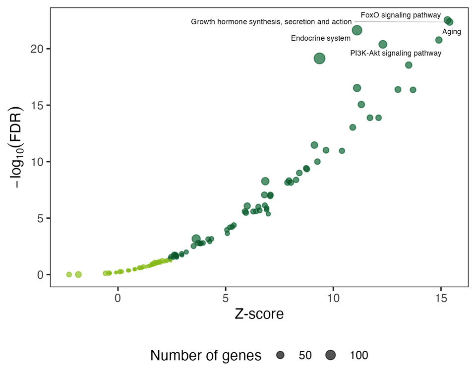

Figure 1: A dotplot of enriched ontology terms. The dots colored in dark green represent the terms with FDR < 0.05, indicating statistical significance. The top 5 significant terms (ordered by FDR ascendingly) are labelled for easier interpretation.

## **Output: Forest Plot**

> **A forest plot** of enriched ontology terms identified using Fisher’s exact test. An editable pdf file is also available for download.

DOWNLOAD .pdf

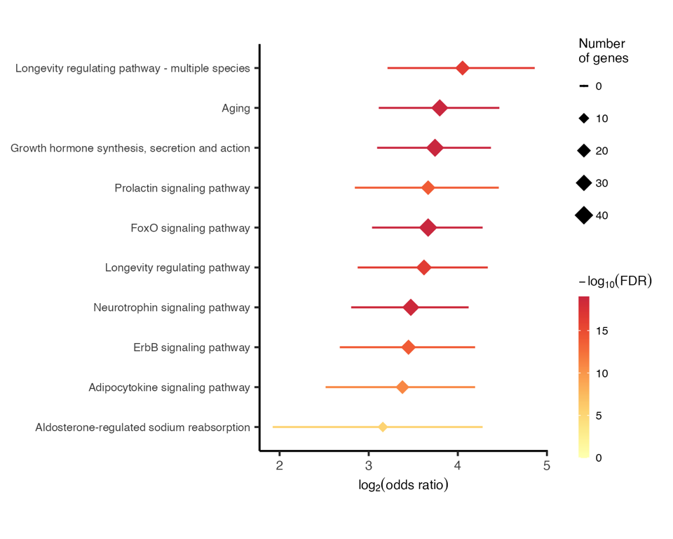

Figure 2: Forest plot for enriched ontology terms (ordered by odds ratio descendingly).